# A comparetive study on PCR, PLS, Envelope and BayesPLS models

4 September 2016

## Overview

- Background
- Estimation methods under comparison
- Data Simulation
- Analysis, Results and Discussions

## Background

- PLS **Population Model** (I. S. Helland, 1990) which further discussed by (I. S. Helland, 2001; Naes & Helland, 1993)
- PLS, *heavely developed* (De Jong, 1993; Naes & Helland, 1993; Wold, 1985), without addressing the population model (R. Cook, Helland, & Su, 2013)
- Mostly popular among chemometrician
- Was not very popular among statistician which has changed and is nowadays considered as an essential tool for multivariate analysis
- Accounting the population model, new estimation methods have been purposed such as **Envelope** (R. D. Cook & Zhang, 2016; R. D. Cook, Li, & Chiaromonte, 2010) and **BayesPLS** (I. S. Helland, Saebø, Tjelmeland, & others, 2012) which are *closely related* to PLS
- R. Cook et al. (2013) said that PLS is fundamentally an envelope in the population model

## Background

- This study attempts to make an *emperial comparison* among PCR, PLS, Envelope and BayesPLS model on the basis of their **prediction ability**
- Using `simrel` (Sæbø, Almøy, & Helland, 2015) R-package, data with diverse nature are simulated.
- `simrel` allows to have control over latent structure (relevant component) of the data, fine analysis of strength and weakness of a models is possible

## Statistical Model

| \(\boldsymbol{Y}_i\) | : | Response vector |
| --- | --- | --- |
| \(\boldsymbol{X}_i\) | : | Matrix of \(p\) predictor variable |
| \(\boldsymbol{\beta}_0\) | : | Intercept term |
| \(\boldsymbol{\beta}\) | : | Regression Coefficients (weight of each predictor variable to describe \(\boldsymbol{Y}\)) |
| \(\boldsymbol{\epsilon}_{i}\) | : | Error vector |

## Statistical Model

All the models under this study, consider a **subspace of predictor variables that is relevant for response**. They differ in the ways of finding the subspace and corresponding model estimates. The true estimates can also be written as,

\[ \begin{aligned} \boldsymbol{\beta} &= \Sigma_{XX}^{-1}\sigma_{Xy} = \sum_{j=1}^p \frac{1}{\alpha_j}\boldsymbol{e}_j\boldsymbol{e}_j^t\sigma_{Xy}\\ &= \sum_{j=1}^p\gamma_j\boldsymbol{e}_j\\ \end{aligned} \]

where,

| \(\gamma_j\) | : \(\frac{\boldsymbol{e}_j^t\sigma_{Xy}}{\lambda_j}\) |
| --- | --- |
| \(\boldsymbol{e}_j\) | : Eigenvector related to \(X\) |
| \(\lambda_j\) | : Eigenvalue related to \(X\) |
| \(\sigma_{Xy}\) | : Covariance between \(y\) and \(X\) |

## Comparison of Methods

| PCR | PLS |
| --- | --- |
| * Regression of response on latent space of predictor | * Estimation through Iterative algorithm |
| * No strict assumption | * No strict assumption |

| Envelope (MLE) | Bayes |
| --- | --- |
| * Estimation using Maximum Likelihood | * Estimation through MCMC approach with rotation of relevant space |
| * Can not be used when predictor is larger than observations | * Heavy Computation when \(p\) is large |

## Data Simulation

Models are analysed under diverse nature of data. Data are simulated using `simrel` package (R). In this study, I have included following four design;

| n | p | R2 | relpos | gamma | q |
| --- | --- | --- | --- | --- | --- |
| 50 | 15 | 0.5 | 1, 2 | 0.5 | 15 |
| 50 | 40 | 0.5 | 1, 2 | 0.5 | 40 |
| 50 | 15 | 0.9 | 2, 3 | 0.9 | 15 |
| 50 | 40 | 0.9 | 2, 3 | 0.9 | 40 |

| `n` | : | Number of observations |
| --- | --- | --- |
| `p` | : | Number of variables |
| `R2` | : | Variation explained by the model |
| `relpos` | : | Position of relevant components |
| `gamma` | : | Reduction factor of eigenvalue of \(X\) |
| `q` | : | number of relevant predictors |

## Model assessment

Models are compared on the basis of their prediction ability by measuring *test* and *training* **mean prediction error**. Mean prediction error is calculated as,

\[ \begin{aligned} \left(\text{Prediction Error}\right)_\text{training} &= \frac{1}{n}\sum_{i = 1}^n\left({\boldsymbol{y}_i - \hat{\boldsymbol{y}}_i}\right)^2 = \frac{1}{n}\sum_{i = 1}^n\left({\boldsymbol{y}_i - \left(\hat{\boldsymbol{\beta}}_0 + \hat{\boldsymbol{\beta}}\boldsymbol{X}_i\right)}\right)^2 \\ \left(\text{Prediction Error}\right)_\text{test} &= \frac{1}{n}\sum_{i = 1}^n\left({\boldsymbol{y}_{i\left(\text{test}\right)} - \hat{\boldsymbol{y}}_{i\left(\text{test}\right)}}\right)^2 \\ &= \frac{1}{n}\sum_{i = 1}^n\left({\boldsymbol{y}_{i\left(\text{test}\right)} - \left(\hat{\boldsymbol{\beta}}_0 + \hat{\boldsymbol{\beta}}\boldsymbol{X}_{i\left(\text{test}\right)}\right)}\right)^2 \end{aligned} \]

## Analysis Results

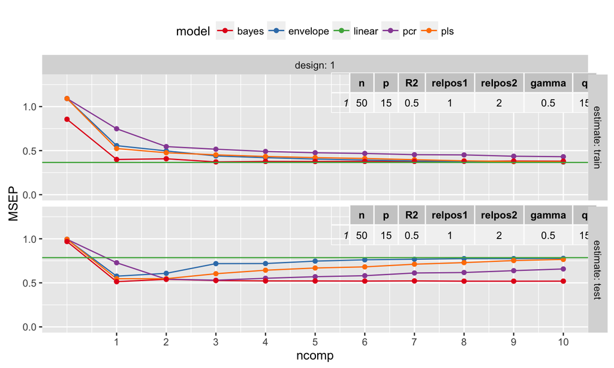

## Analysis Results

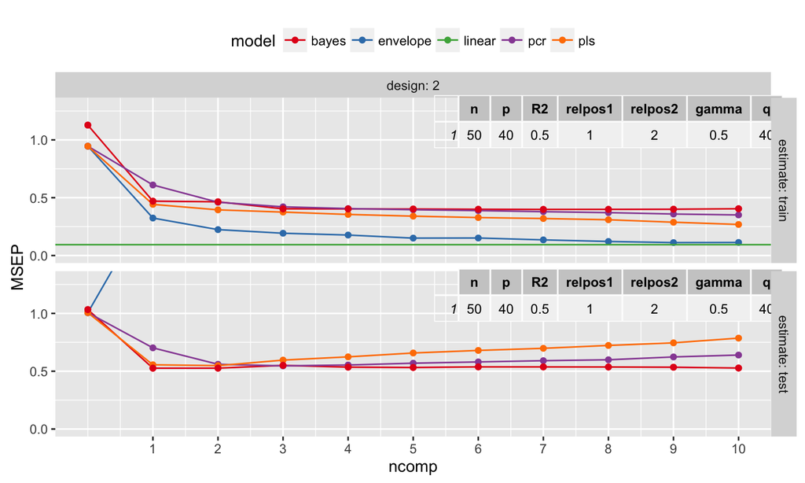

## Analysis Results

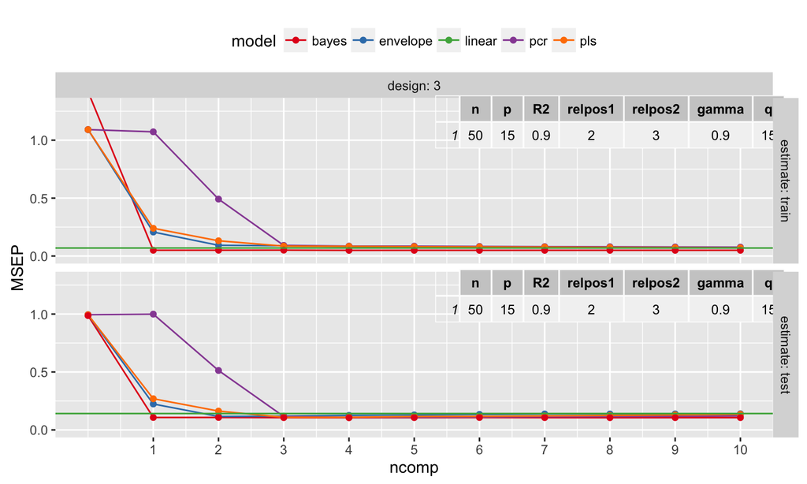

## Analysis Results

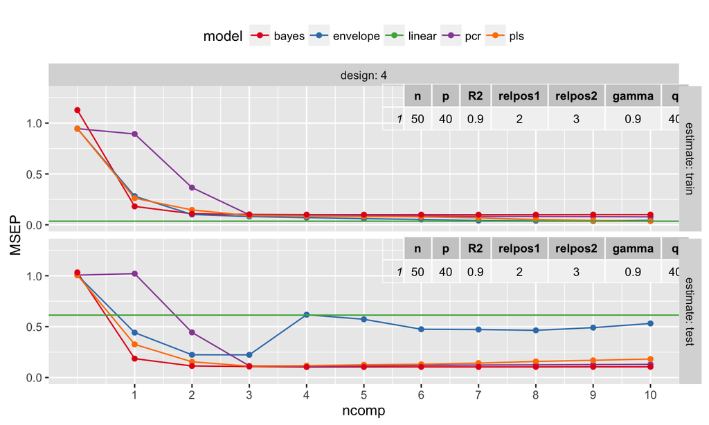

## Analysis Results

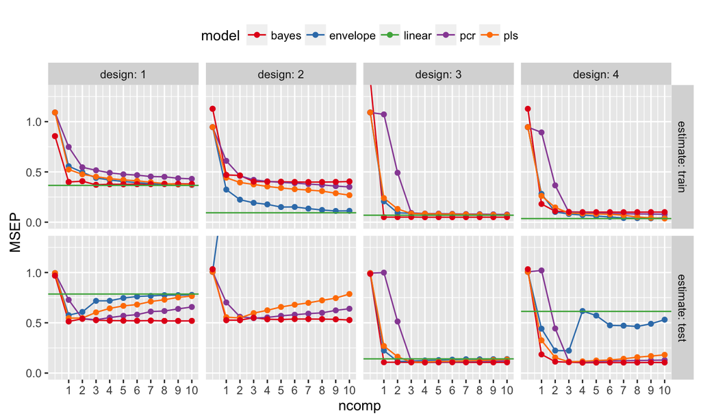

## References

## References

Cook, R. D., & Zhang, X. (2016). Algorithms for envelope estimation. *Journal of Computational and Graphical Statistics*, *25*(1), 284–300.

Cook, R. D., Li, B., & Chiaromonte, F. (2010). Envelope models for parsimonious and efficient multivariate linear regression. *Statistica Sinica*, 927–960.

Cook, R., Helland, I., & Su, Z. (2013). Envelopes and partial least squares regression. *Journal of the Royal Statistical Society: Series B (Statistical Methodology)*, *75*(5), 851–877.

De Jong, S. (1993). SIMPLS: An alternative approach to partial least squares regression. *Chemometrics and Intelligent Laboratory Systems*, *18*(3), 251–263.

Helland, I. S. (1990). Partial least squares regression and statistical models. *Scandinavian Journal of Statistics*, 97–114.

Helland, I. S. (2001). Some theoretical aspects of partial least squares regression. *Chemometrics and Intelligent Laboratory Systems*, *58*(2), 97–107.

Helland, I. S., Saebø, S., Tjelmeland, H., & others. (2012). Near optimal prediction from relevant components. *Scandinavian Journal of Statistics*, *39*(4), 695–713.

Naes, T., & Helland, I. S. (1993). Relevant components in regression. *Scandinavian Journal of Statistics*, 239–250.

Sæbø, S., Almøy, T., & Helland, I. S. (2015). Simrel—A versatile tool for linear model data simulation based on the concept of a relevant subspace and relevant predictors. *Chemometrics and Intelligent Laboratory Systems*, *146*, 128–135.

Wold, H. (1985). Partial least squares. *Encyclopedia of Statistical Sciences*.